# Pension returns analysis

# PFA high risk (phr), 2011 - 2023

## QQ Plot

Skewed $t$-distribution (sstd):

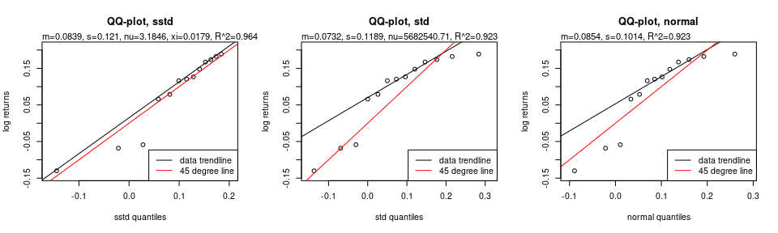

## Data vs fit

Let’s plot the fit and the observed returns together.

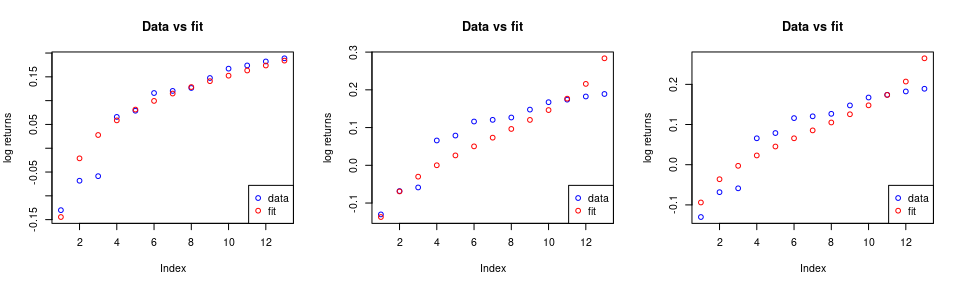

## Estimated distribution

Now lets look at the CDF of the estimated distribution for each 0.1% increment between 0.5% and 99.5% for the estimated distribution:

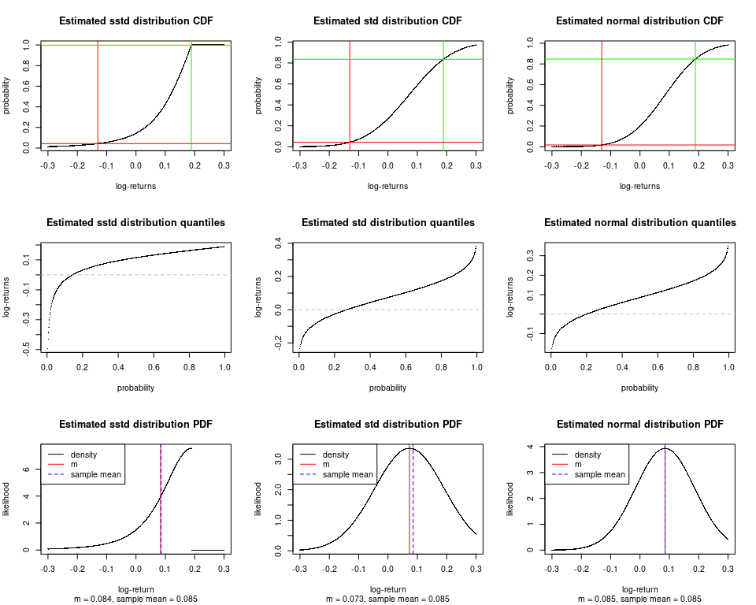

## Monte Carlo

Sorted portfolio index values for last period of all runs

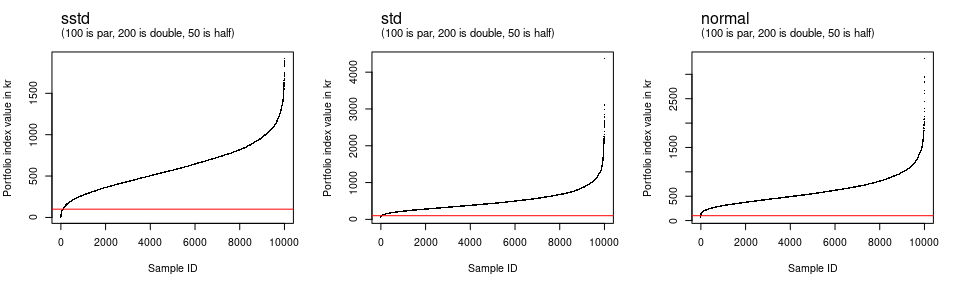

## Convergence

### Max vs sum

Max vs sum plots for the first four moments:

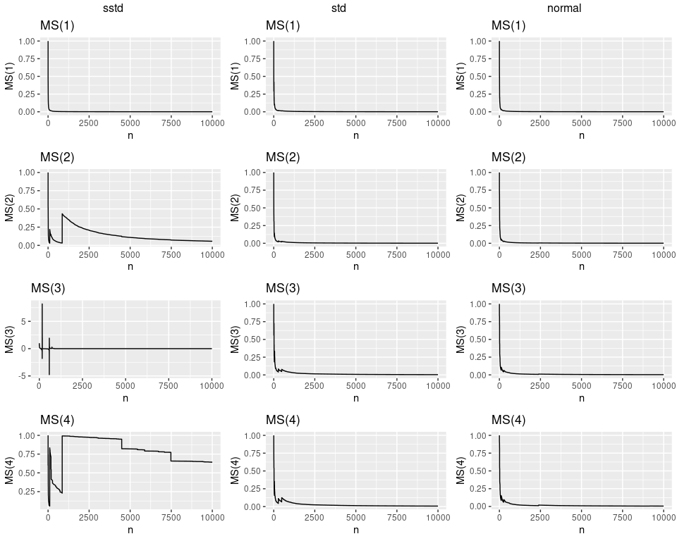

### MC

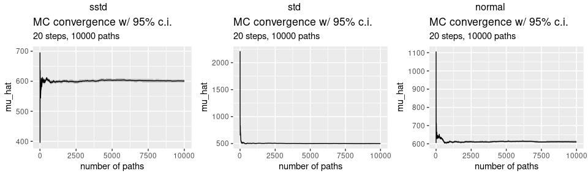

### IS

Skewed $t$-distribution with a normal proposal distribution.

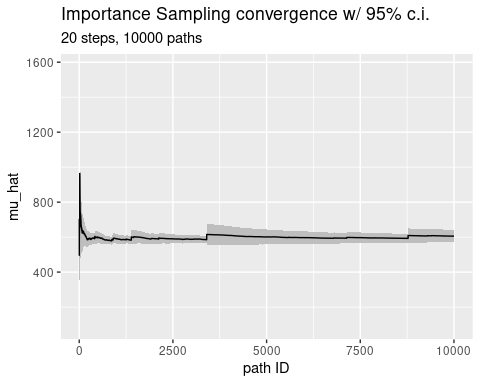

Parameters

```
## [1] 1.8379614 0.4397688
```

Objective function plots

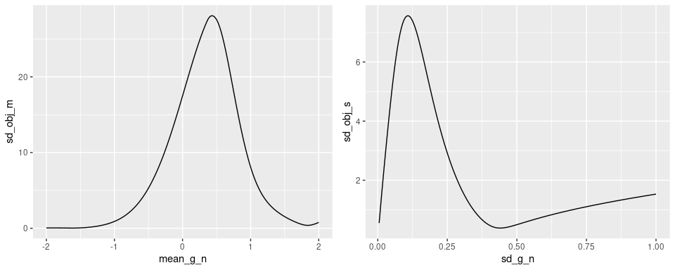

# Mix medium risk (mmr), 2011 - 2023

## QQ Plot

Skewed $t$-distribution (sstd):

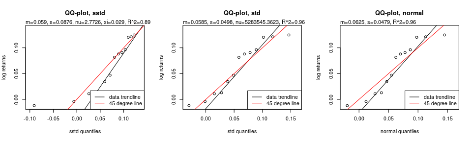

## Data vs fit

Let’s plot the fit and the observed returns together.

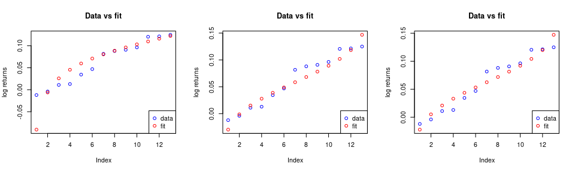

## Estimated distribution

Now lets look at the CDF of the estimated distribution for each 0.1% increment between 0.5% and 99.5% for the estimated distribution:

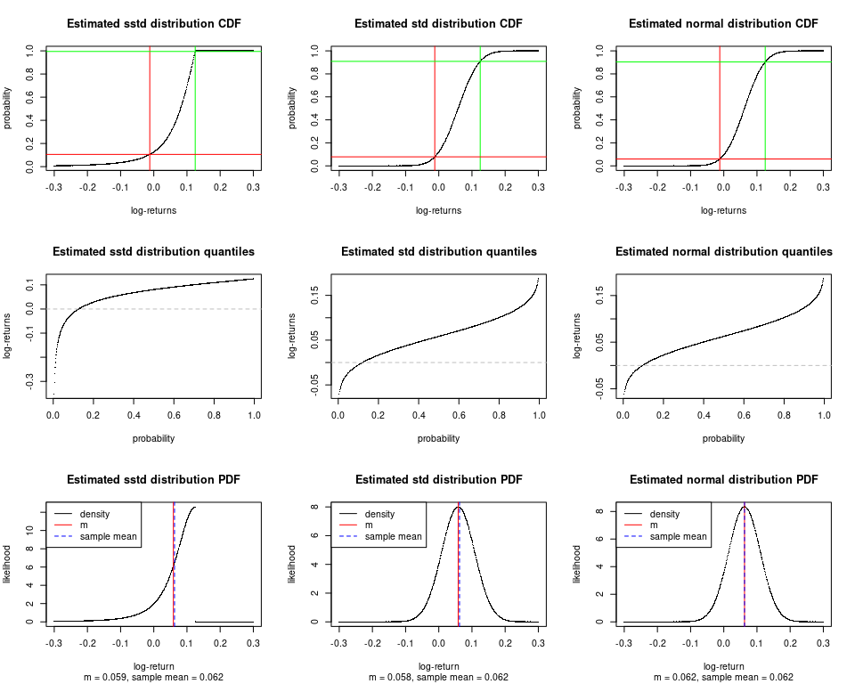

## Monte Carlo

Sorted portfolio index values for last period of all runs

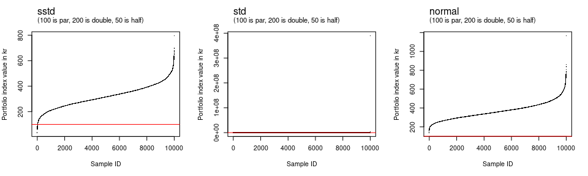

## Convergence

### Max vs sum

Max vs sum plots for the first four moments:

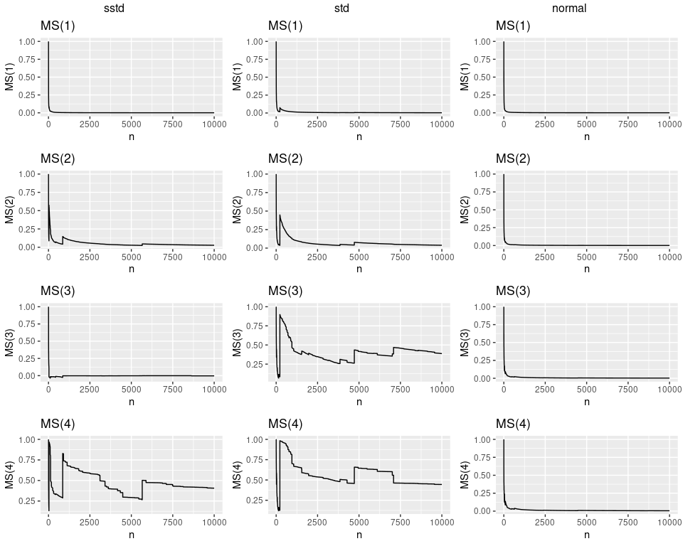

### MC

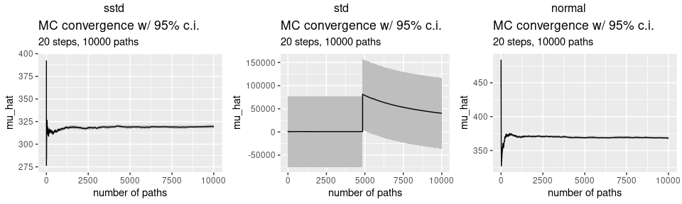

### IS

Skewed $t$-distribution with a normal proposal distribution.

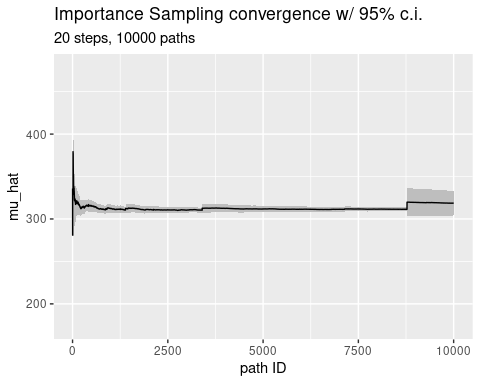

Parameters

```
## [1] 1.1948623 0.2654885
```

Objective function plots

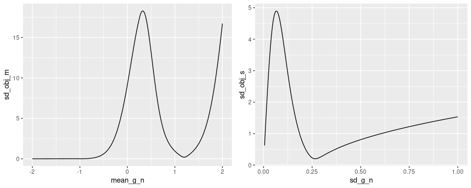

# Mix high risk (mhr), 2011 - 2023

## QQ Plot

Skewed $t$-distribution (sstd):

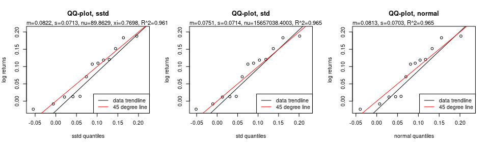

## Data vs fit

Let’s plot the fit and the observed returns together.

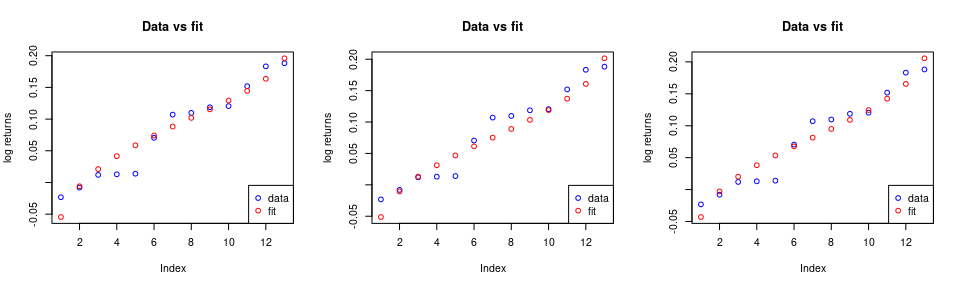

## Estimated distribution

Now lets look at the CDF of the estimated distribution for each 0.1% increment between 0.5% and 99.5% for the estimated distribution:

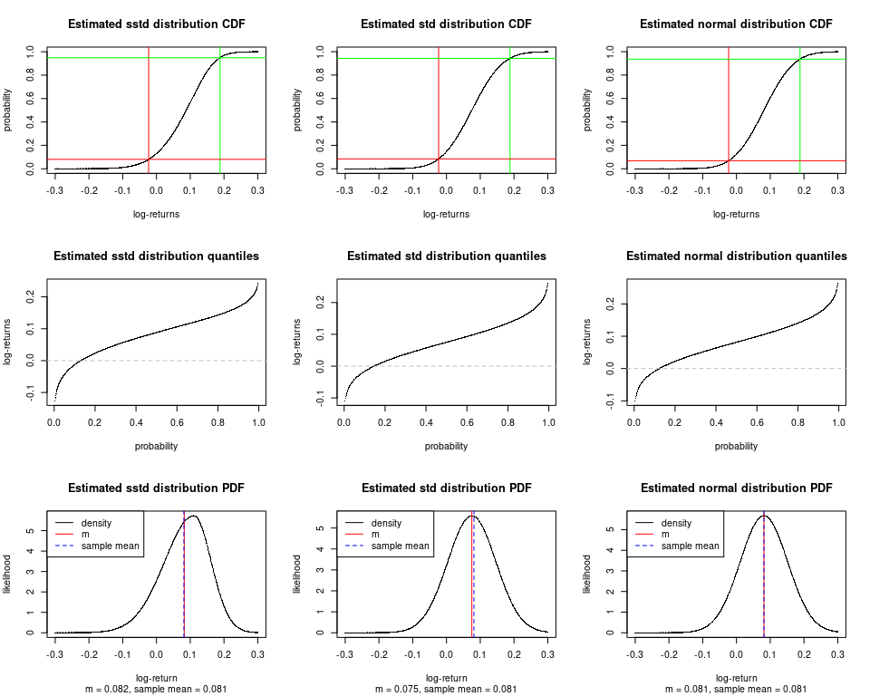

## Monte Carlo

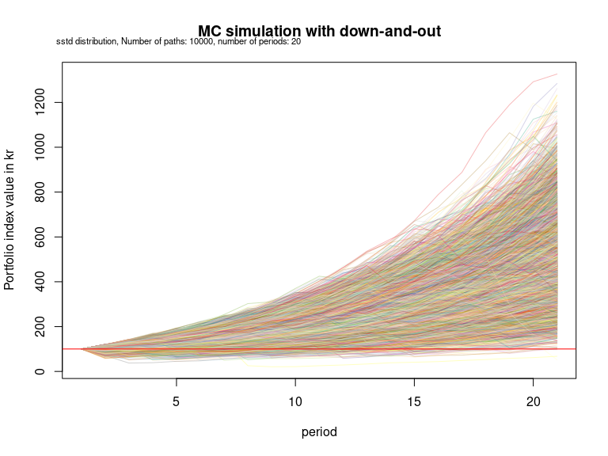

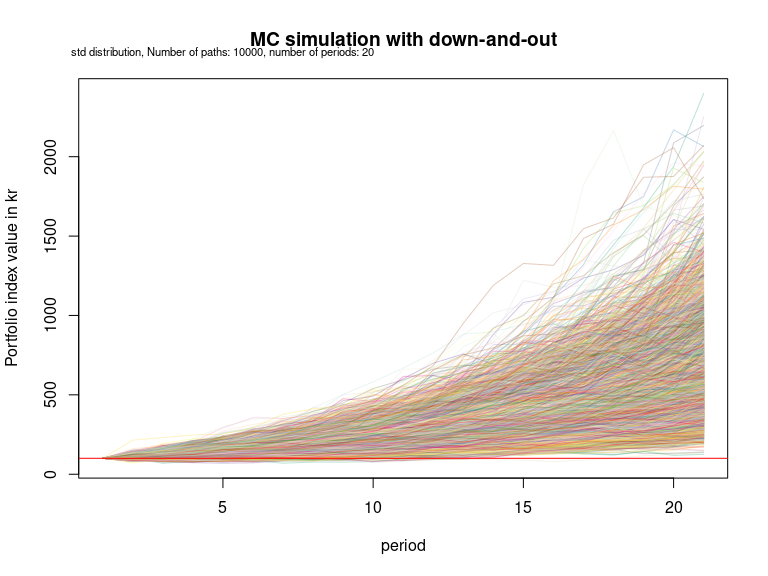

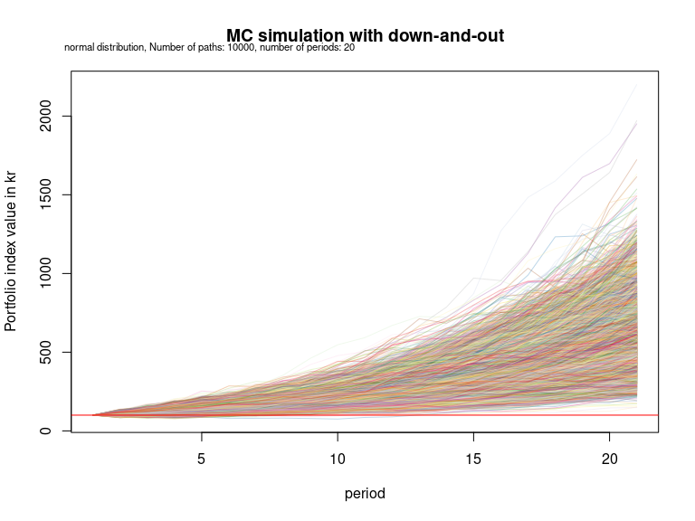

Sorted portfolio index values for last period of all runs

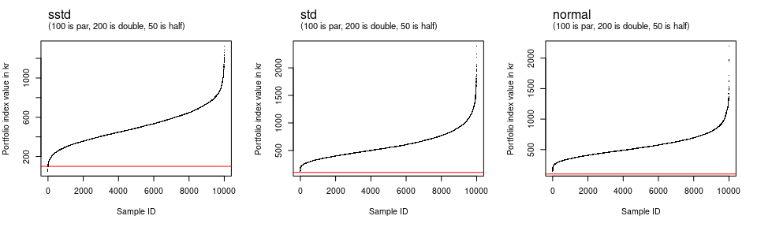

## Convergence

### Max vs sum

Max vs sum plots for the first four moments:

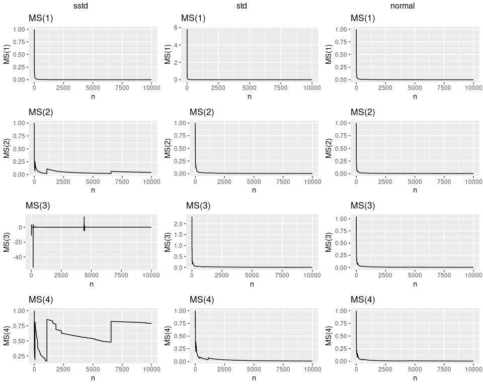

### MC

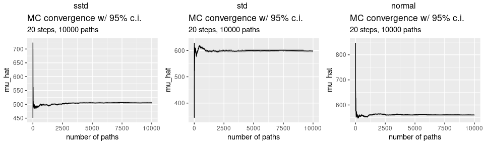

### IS

Skewed $t$-distribution with a normal proposal distribution.

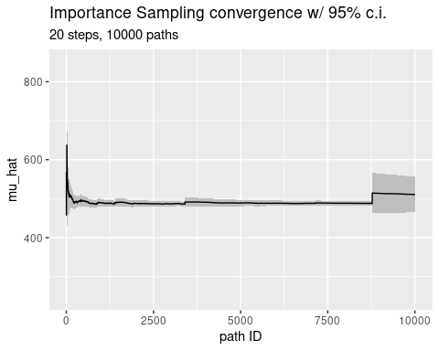

Parameters

```
## [1] 1.6413478 0.3380133
```

Objective function plots

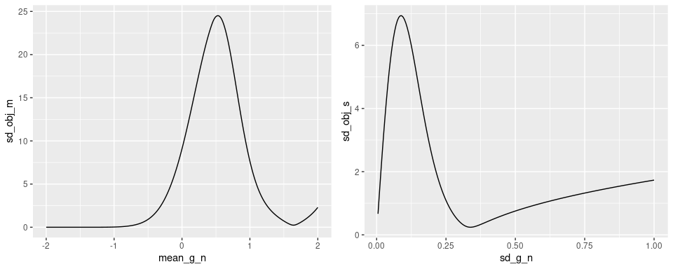

# Mix vmr+phr (vm_ph), 2011 - 2023

## QQ Plot

Skewed $t$-distribution (sstd):

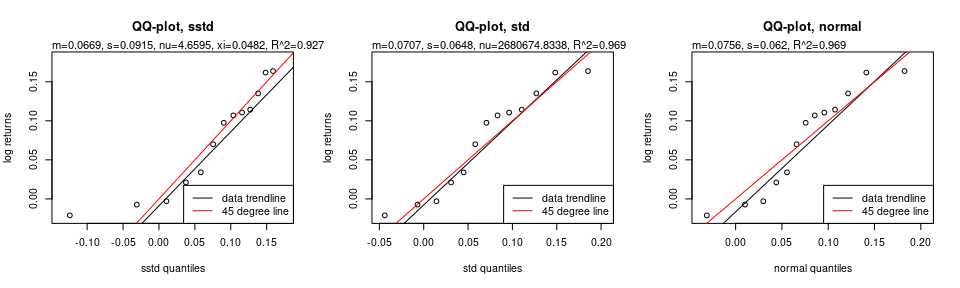

## Data vs fit

Let’s plot the fit and the observed returns together.

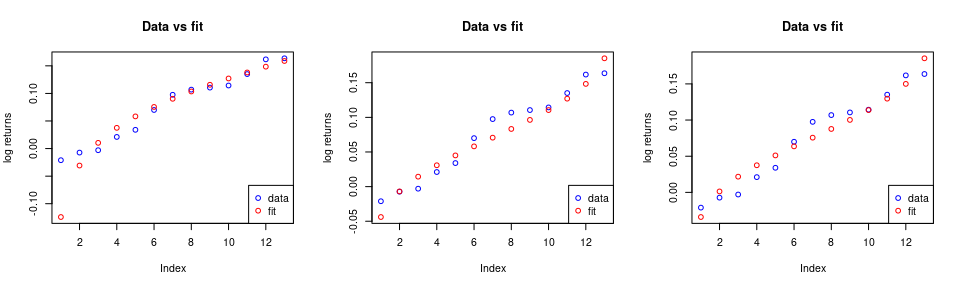

## Estimated distribution

Now lets look at the CDF of the estimated distribution for each 0.1% increment between 0.5% and 99.5% for the estimated distribution:

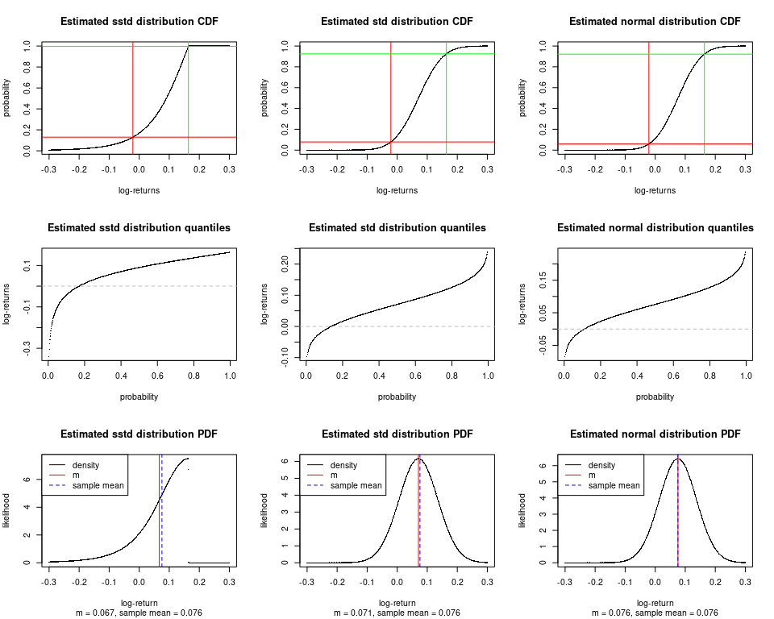

## Monte Carlo

Sorted portfolio index values for last period of all runs

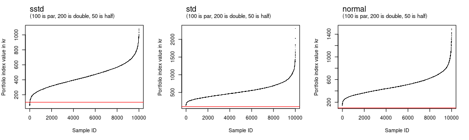

## Convergence

### Max vs sum

Max vs sum plots for the first four moments:

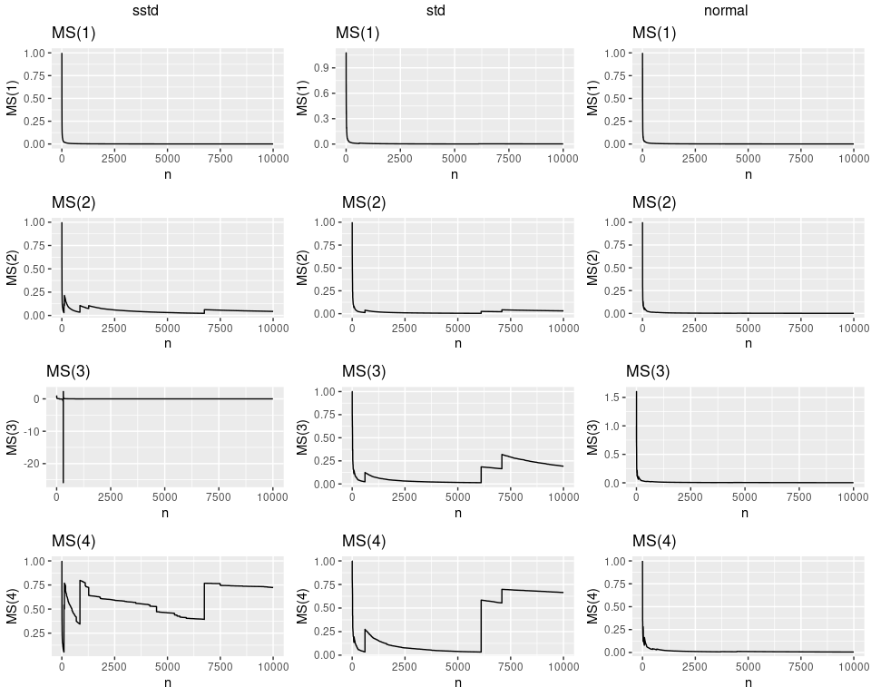

### MC

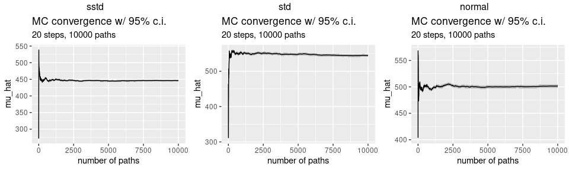

### IS

Skewed $t$-distribution with a normal proposal distribution.

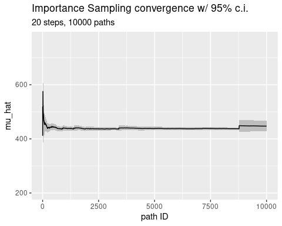

Parameters

```
## [1] 1.5363616 0.3304634
```

Objective function plots

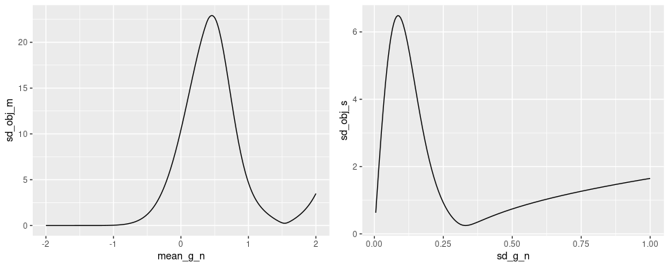

# Mix vhr+pmr (mh_pm), 2011 - 2023

## QQ Plot

Skewed $t$-distribution (sstd):

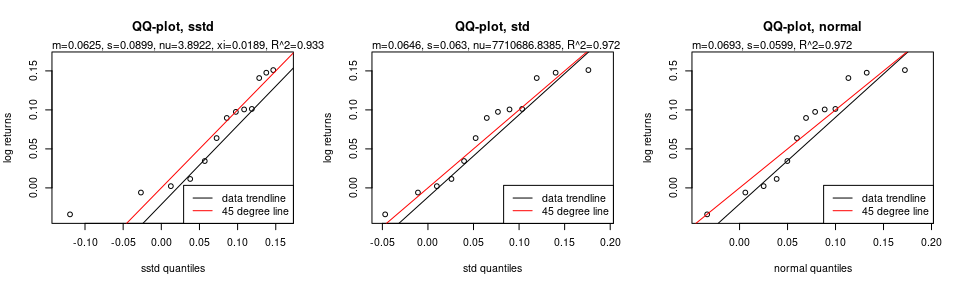

## Data vs fit

Let’s plot the fit and the observed returns together.

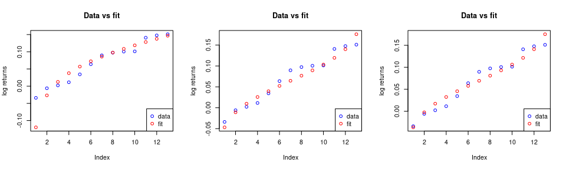

## Estimated distribution

Now lets look at the CDF of the estimated distribution for each 0.1% increment between 0.5% and 99.5% for the estimated distribution:

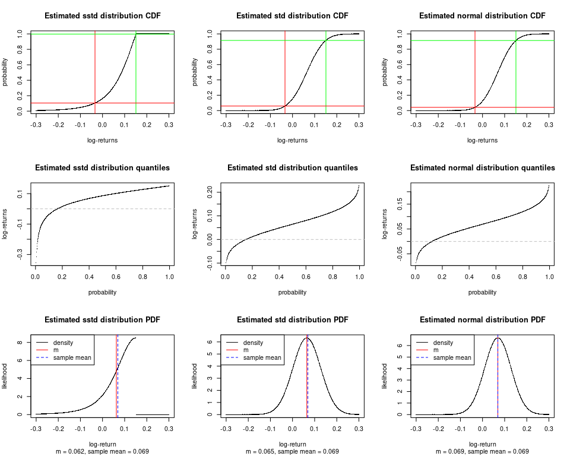

## Monte Carlo

Sorted portfolio index values for last period of all runs

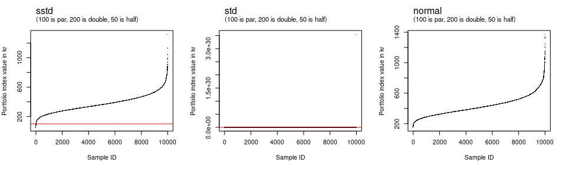

## Convergence

### Max vs sum

Max vs sum plots for the first four moments:

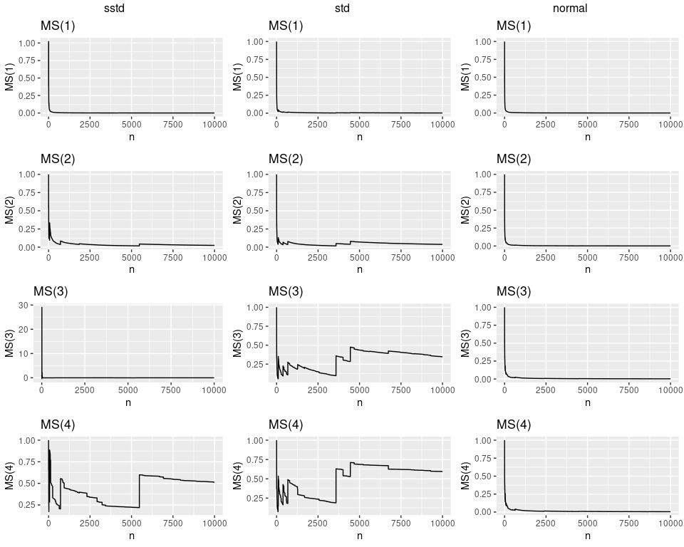

### MC

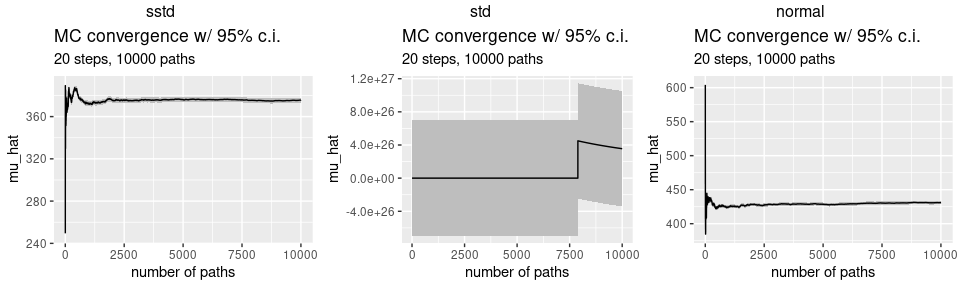

### IS

Skewed $t$-distribution with a normal proposal distribution.

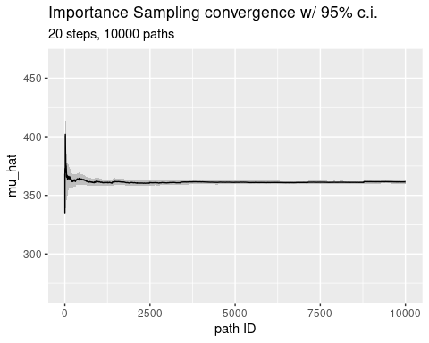

Parameters

```
## [1] 1.3625460 0.3050122
```

Objective function plots

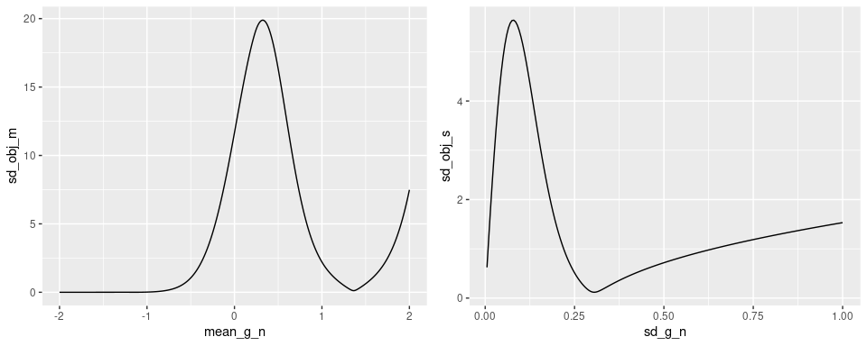

# Comments

`mhr` has some nice properties:

Taleb, Statistical Consequences Of Fat Tails, p. 97:  
“the variance of a finite variance random variable with tail exponent $< 4$ will be infinite”.

And p. 363:  
“The hedging errors for an option portfolio (under a daily revision regime) over 3000 days, under a constant volatility Student T with tail exponent $\alpha = 3$. Technically the errors should not converge in finite time as their distribution has infinite variance.”

- Note: QQ lines by design pass through 1st and 3rd quantiles. They are not trendlines in the sense of linear regression.

# Appendix

## Many simulations of mc_mhr: `num_paths = 1e6`

1e6 paths:

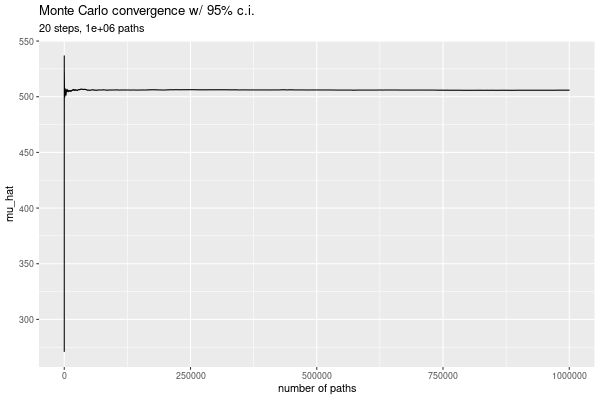

Compare $10^6$ and $10^4$ paths for mhr:

|  | mc_m | mc_s | mc_min | mc_max | dao_pct | dai_pct |
| --- | --- | --- | --- | --- | --- | --- |
| mc_mhr_1e6 | 505.90695 | 173.22176 | 21.09569 | 1734.83520 | 0.00000 | 0.07330 |
| mc_mhr_1e4 | 505.47920 | 172.23152 | 51.70735 | 1326.58266 | 0.00000 | 0.04000 |
| is_mhr_1e4 | 510.836 | 2331.167 | 205.398 | 232384.846 | ibid. | ibid. |

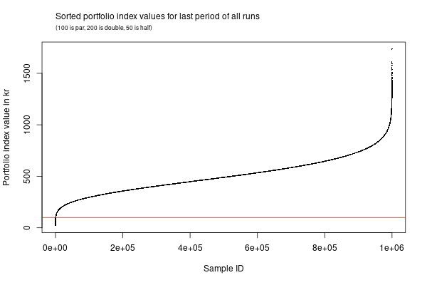

## Arithmetic vs geometric mean

Let $m$ be the number of steps in each path and $n$ be the number of paths. $a$ is the initial capital. Use arithmetic mean for mean of all paths at time $t$:
$$\dfrac{a
(e^{z_1} + e^{z_2} + \dots + e^{z_n})}{n}$$
where
$$z_i := x_{i, 1} + x_{i, 2} + \dots + x_{i,
m}$$
Use geometric mean for mean of all steps in a single path $i$:
$$a
e^{\frac{x_{i, 1} + x_{i, 2} + \dots + x_{i, m}}{m}} = a
\sqrt[m]{e^{x_{i, 1} + x_{i, 2} + \dots + x_{i, m}}}$$

So for **Monte Carlo** of returns after $m$ periods, we

- fit a skewed t-distribution to log-returns and use that distribution to simulate $\{x_{i, j}\}_j^m$,
- for each path $i$, calculate $100\cdot e^{z_i}$,
- calculate the mean of $\{z_i\}_i^n$:
  - $$\bar{z} = 100\dfrac{e^{z_1} + e^{z_2} +
    \dots + e^{z_n}}{n}$$

For **Importance Sampling**, we

- model log-returns on a skewed t-distribution,
- for each path $i$, calculate $100\cdot e^{z_i}$,
- fit a skewed t-distribution to $\{z_i\}_i^n$ and use it as our $f$ density function from which we simulate $\{h_i\}_i^n$,
  - In our case $h$ and $z$ are identical, because we have an idea for a distribution to simulate $z$, but in general for IS $h$ could be a function of $z$.
- calculate $w* = \frac{f}{g^*}$, where $g*$ is our proposal distribution, which minimizes the variance of $h\cdot w$.
- calculate the arithmetic mean of $\{h_i w_i^{*}\}_i^n$:
  - $$100 \dfrac{e^{h_1 w_1^{*}} + e^{h_2
    w_2^{*}} + \dots + e^{h_n w_n^{*}}}{n}$$

## Average of returns vs returns of average

### Math

$$\text{Avg. of returns} := \dfrac{
\left(\dfrac{x_t}{x_{t-1}} + \dfrac{y_t}{y_{t-1}} \right) }{2}$$
$$\text{Returns of avg.} := \left(\dfrac{ x_t
+ y_t }{2}\right) \Big/ \left(\dfrac{ x_{t-1} + y_{t-1} }{2}\right)
\equiv \dfrac{ x_t + y_t }{ x_{t-1} + y_{t-1}}$$

For which $x_1$ and $y_1$ are $\text{Avg. of returns} = \text{Returns of avg.}$?

$$\dfrac{ \left(\dfrac{x_t}{x_{t-1}} +
\dfrac{y_t}{y_{t-1}} \right) }{2} = \dfrac{ x_t + y_t }{ x_{t-1} +
y_{t-1}}$$

$$\dfrac{x_t}{x_{t-1}} +
\dfrac{y_t}{y_{t-1}} = 2 \dfrac{ x_t + y_t }{ x_{t-1} +
y_{t-1}}$$

$$(x_{t-1} + y_{t-1}) x_t y_{t-1} +
(x_{t-1} + y_{t-1}) x_{t-1} y_t = 2 (x_{t-1}y_{t-1}x_t +
x_{t-1}y_{t-1}y_t)$$

$$(x_{t-1}x_ty_{t-1} + y_{t-1}x_ty_{t-1})
+ (x_{t-1}x_{t-1}y_t + x_{t-1}y_{t-1}y_t) = 2(x_{t-1}y_{t-1}x_t +
x_{t-1}y_{t-1}y_t)$$
This is not generally true, but true if for instance $x_{t-1} = y_{t-1}$.

### Example

Definition: `R = 1+r`

```
## Let x_0 be 100.
```

```
## Let y_0 be 200.
```

```
## So the initial value of the pf is 300 .
```

```
## Let R_x be 0.5.
```

```
## Let R_y be 1.5.
```

Then,

```
## x_1 is R_x * x_0 = 50.
```

```
## y_1 is R_y * y_0 = 300.
```

Average of returns:

```
## 0.5 * (R_x + R_y) = 1
```

So here the value of the pf at t=1 should be unchanged from t=0:

```
## (x_0 + y_0) * 0.5 * (R_x + R_y) = 300
```

But this is clearly not the case:

```
## 0.5 * (x_1 + y_1) = 0.5 * (R_x * x_0 + R_y * y_0) = 175
```

Therefore we should take returns of average, not average of returns!

Let’s take the average of log returns instead:

```
## 0.5 * (log(R_x) + log(R_y)) = -0.143841
```

We now get:

```
## (x_0 + y_0) * exp(0.5 * (log(Rx) + log(Ry))) = 259.8076
```

So taking the average of log returns doesn’t work either.

## Simulation of mix vs mix of simulations

Test if a simulation of a mix (average) of two returns series has the same distribution as a mix of two simulated returns series.

```
## m(data_x): 0.07835937
## s(data_x): 0.4045342
## m(data_y): 10.07878
## s(data_y): 3.296439
##
## m(data_x + data_y): 5.078572
## s(data_x + data_y): 1.651354
```

m and s of final state of all paths.  
`_a` is mix of simulated returns.  
`_b` is simulated mixed returns.

| m_a | m_b | s_a | s_b |
| --- | --- | --- | --- |
| 101.752 | 101.779 | 7.589 | 7.501 |
| 101.867 | 101.641 | 7.468 | 7.430 |
| 101.468 | 101.598 | 7.427 | 7.479 |
| 101.430 | 101.726 | 7.331 | 7.369 |
| 101.336 | 101.922 | 7.321 | 7.532 |
| 101.306 | 101.529 | 7.348 | 7.647 |
| 101.597 | 101.263 | 7.477 | 7.415 |
| 101.697 | 101.697 | 7.247 | 7.451 |
| 101.537 | 101.859 | 7.645 | 7.412 |
| 101.574 | 101.682 | 7.723 | 7.490 |

```
##       m_a             m_b             s_a             s_b
##  Min.   :101.3   Min.   :101.3   Min.   :7.247   Min.   :7.369
##  1st Qu.:101.4   1st Qu.:101.6   1st Qu.:7.335   1st Qu.:7.419
##  Median :101.6   Median :101.7   Median :7.447   Median :7.465
##  Mean   :101.6   Mean   :101.7   Mean   :7.457   Mean   :7.473
##  3rd Qu.:101.7   3rd Qu.:101.8   3rd Qu.:7.561   3rd Qu.:7.498
##  Max.   :101.9   Max.   :101.9   Max.   :7.723   Max.   :7.647
```

`_a` and `_b` are very close to equal.  
We attribute the differences to differences in estimating the distributions in version a and b.

The final state is independent of the order of the preceding steps:

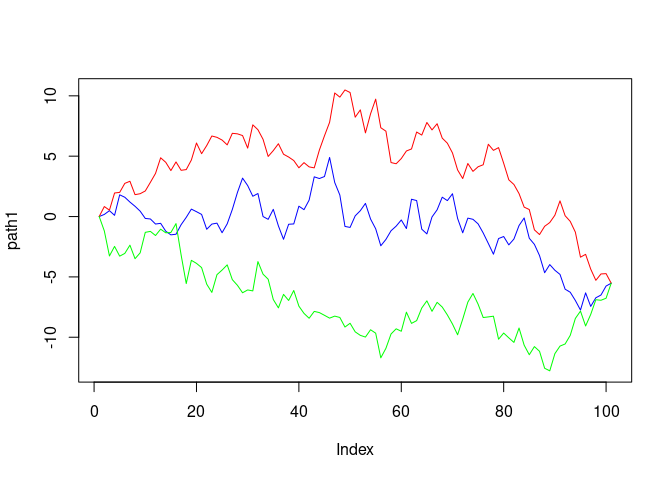

So does the order of the steps in the two processes matter, when mixing simulated returns?

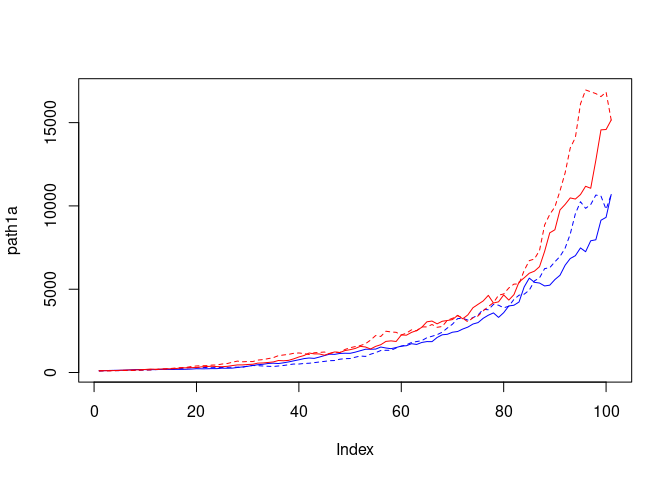

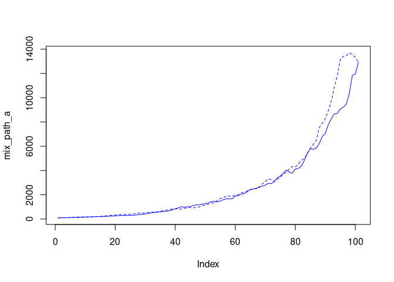

The order of steps in the individual paths do not matter, because the mix of simulated paths is a sum of a sum, so the order of terms doesn’t affect the sum. If there is variation it is because the sets preceding steps are not the same. For instance, the steps between step 1 and 60 in the plot above are not the same for the two lines.

Recall,
$$\text{Var}(aX+bY) = a^2
\text{Var}(X) + b^2 \text{Var}(Y) + 2ab \text{Cov}(a, b)$$

```r
var(0.5 * vhr + 0.5 * phr)
```

```
## [1] 0.005355618
```

```r
0.5^2 * var(vhr) + 0.5^2 * var(phr) + 2 * 0.5 * 0.5 * cov(vhr, phr)
```

```
## [1] 0.005355618
```

Our distribution estimate is based on 13 observations. Is that enough for a robust estimate? What if we suddenly hit a year like 2008? How would that affect our estimate?  
Let’s try to include the Velliv data from 2007-2010.  
We do this by sampling 13 observations from `vmrl`.

```
##        m                 s
##  Min.   :0.05947   Min.   :0.03798
##  1st Qu.:0.06631   1st Qu.:0.05963
##  Median :0.07057   Median :0.06564
##  Mean   :0.07086   Mean   :0.06590
##  3rd Qu.:0.07614   3rd Qu.:0.07166
##  Max.   :0.08109   Max.   :0.08840
```

## The meaning of `xi`

The fit for `mhr` has the highest `xi` value of all. This suggests right-skew:

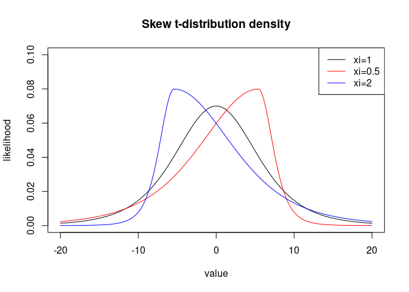

## Max vs sum plot

If the Law Of Large Numbers holds true,
$$\dfrac{\max (X_1^p, ..., X^p)}{\sum_{i=1}^n
X_i^p} \rightarrow 0$$
for $n \rightarrow \infty$.

If not, $X$ doesn’t have a $p$’th moment.

See Taleb: The Statistical Consequences Of Fat Tails, p. 192